# Bootstrap 2

## 1. Introduction to Bootstrap test

한 모집단의 모평균에 대한 검정법을 기억해 보자.

$$H_0 : \mu=\mu_0 ~~~vs~~~\mu>\mu_0$$

과 같은 가설을 검정하기 위한 검정통계량은 $(\bar X - \mu_0)/(S/\sqrt{n})$이고 귀무가설 하에서

$$(\bar X - \mu_0)/(S/\sqrt{n}) \approx N(0,1),~~for~large~n$$

임을 이용해서 검정을 수행할 수 있다. 이 때 검정통계량의 관측치가 $z_0$라면, $p$-value는

$$P(Z>z_0)$$

로 주어진다. 즉, 검정을 위해서는 귀무가설 하에서 검정통계량의 분포를 아는 것이 핵심이다.

위와 같은 일표본 위치검정 문제를 시뮬레이션 기법에 근거하여 수행해 보자.

1. 만약 모집단이 정규분포라는 가정을 할 수 있다면, $N(\mu_0,S^2)$으로부터 붓스트랩 표본을 $B$번 반복하여 추출하여 검정통계량의 분포를 추정할 수 있을 것이다. 이 경우 $p$-value는 다음과 같이 추정된다.

$$\hat p = \frac{\# \{\bar X^\ast \geq z_0\}}{B}$$

2. 하지만, 모집단이 특정한 분포라는 가정을 할 수 없다면? 이 경우 귀무가설 하에서 붓스트랩 표본을 뽑는 것이 간단하지 않다.
17. $\hat F_n$으로부터 붓스트랩 표본을 뽑아 검정통계량의 분포를 추정하는 것이 왜 불가능한지 생각해 보아라.

## 2. One-sample test

$H_0 : \mu\mu_0$일 때, 검정통계량을

$$\frac{\bar X - \mu_0}{S/\sqrt{n}}$$

으로 한다. 모집단의 분포를 $F$, 귀무가설 하에서의 분포를 $F_0$($F$를 평행이동한 분포)라고 하자. 즉, $F_0$는 평균이 $\mu_0$인 분포이다. $\hat F_n$은 평균이 $\mu$인 분포이다. 즉, $\tilde X_i = X_i - mu + \mu_0$로 정의하면, $X_i'$은 평균이 $\mu_0$인 분포(즉, $F_0$)를 가질 것이다. 따라서, $X_i'$에 의해 shifted-EDF를 만들고 그 분포로부터 붓스트랩 표본을 추출하면 된다. 단, $\mu$는 미지의 모수이므로, 추정량 $\bar X$로 대체한다.

- step 1 : $\tilde X_i = X_i - \bar X + \mu_0$ 계산
- step 2 : $\tilde X_i$으로부터 $B$회 붓스트랩 표본 추출
- step 3 : 각 붓스트랩 표본으로부터 표본평균 $\bar{\tilde X}^\ast_b$ 계산
- step 4 :
  $$\hat p = \frac{\# \{\bar{\tilde X}^\ast_b \geq z_0\}}{B}$$
- Example : $N(0,1)$, test $H_0 : \mu=0$

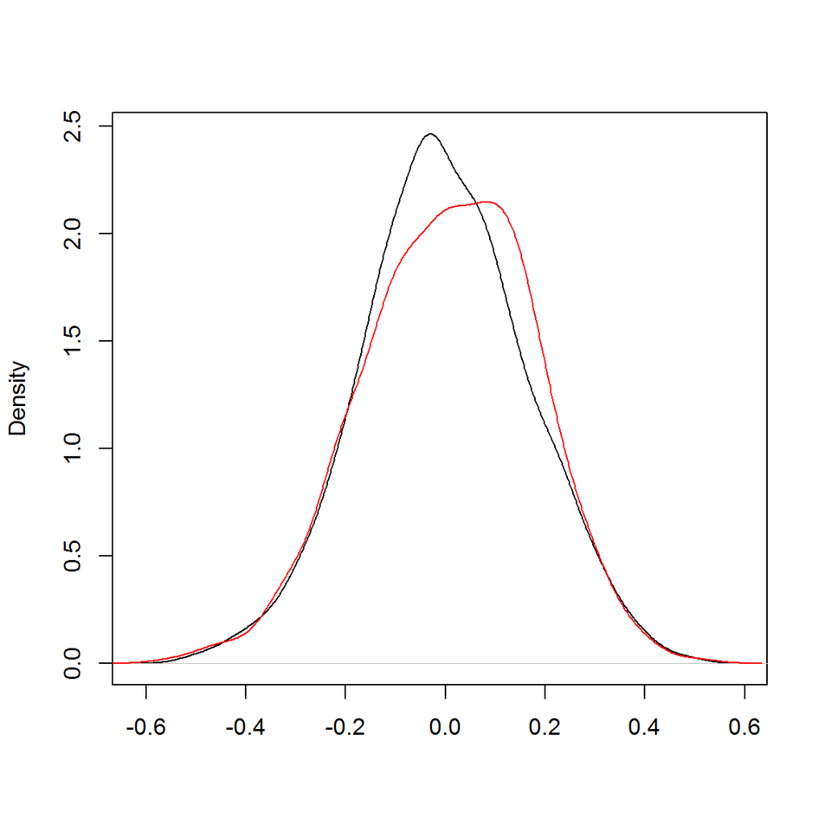

```r
B=1000
set.seed(1)
x=rnorm(30)
BS=BS1=matrix(0,B,length(x))
Bm=Bm1=c()
for (i in 1:B)
  {
  BS[i,]=rnorm(length(x),0,sd(x))
  Bm[i]=mean(BS[i,])
  BS1[i,]=sample(x-mean(x)+0,replace=T)
  Bm1[i]=mean(BS1[i,])
}
plot(density(Bm),main="",xlab="")
lines(density(Bm1),col=2)
```

```r
p=mean(Bm>mean(x))    # p-value based on Normality
p1=mean(Bm1>mean(x))  # p-value based on shifted EDF
c(p,p1)
```

```
## [1] 0.293 0.354
```

- Example : $N(1,1)$, test $H_0 : \mu=0.5$

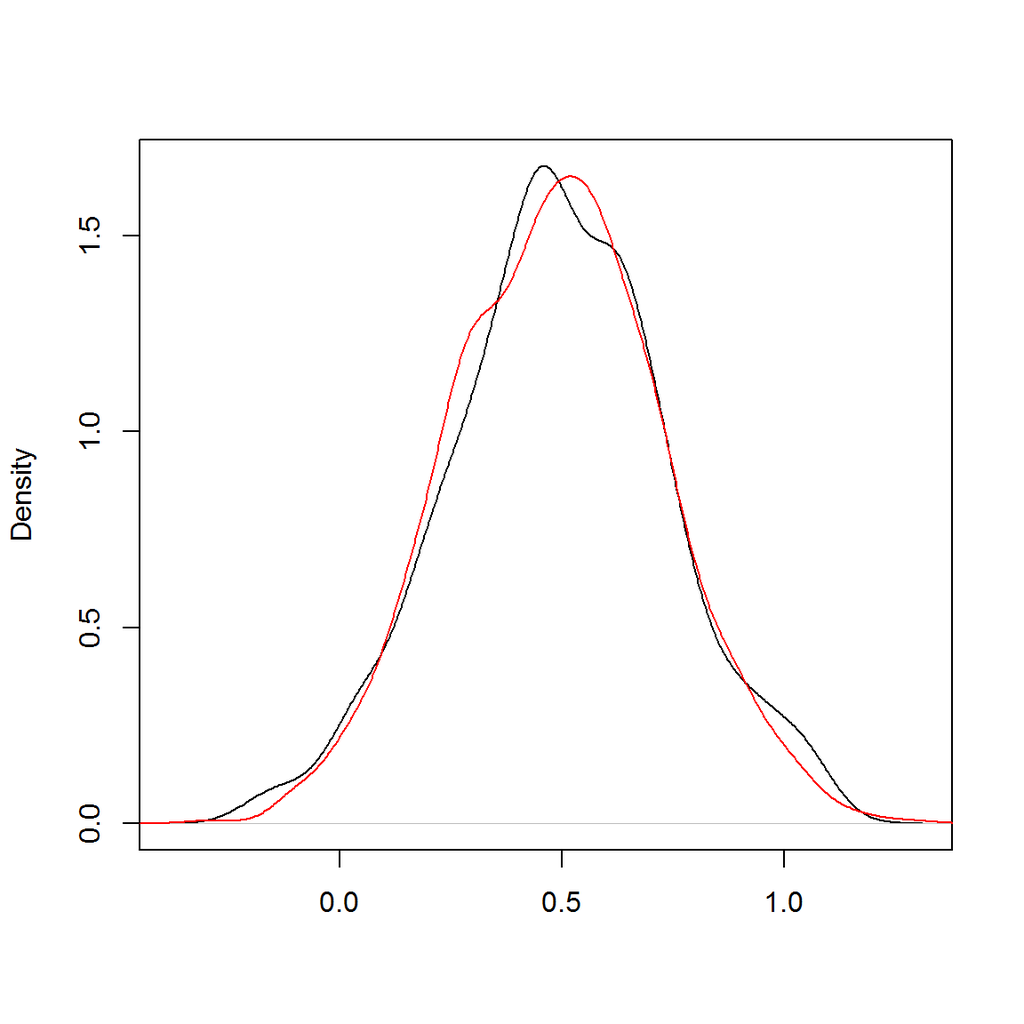

```r
B=1000
x=rnorm(30,1,1)
BS=BS1=matrix(0,B,length(x))
Bm=Bm1=c()
for (i in 1:B)
  {
  BS[i,]=rnorm(length(x),0.5,sd(x))
  Bm[i]=mean(BS[i,])
  BS1[i,]=sample(x-mean(x)+0.5,replace=T)
  Bm1[i]=mean(BS1[i,])
}
plot(density(Bm),main="",xlab="")
lines(density(Bm1),col=2)
```

```r
p=mean(Bm>mean(x))    # p-value based on Normality
p1=mean(Bm1>mean(x))  # p-value based on shifted EDF
c(p,p1)
```

```
## [1] 0.066 0.055
```

```r
for (i in 1:B)
  {
  BS1[i,]=sample(x,replace=T)
  Bm1[i]=mean(BS1[i,])
}
mean(Bm1>mean(x))     # wrong p-value
```

```
## [1] 0.475
```

## 3. Two-sample test

와 같이 할 수 있다. (공통분산의 경우) 귀무가설 하에서 두 모집단은 같은 분포함수를 가진다고 할 수 있으므로 모든 표본을 풀링하여 구성한 EDF $\hat F_p$으로부터 붓스트랩 표본을 추출할 수 있다.

- Example : $N(1,1)$과 $N(0,1)$로부터 각각 12개 8개씩의 표본을 뽑은 후에 검정

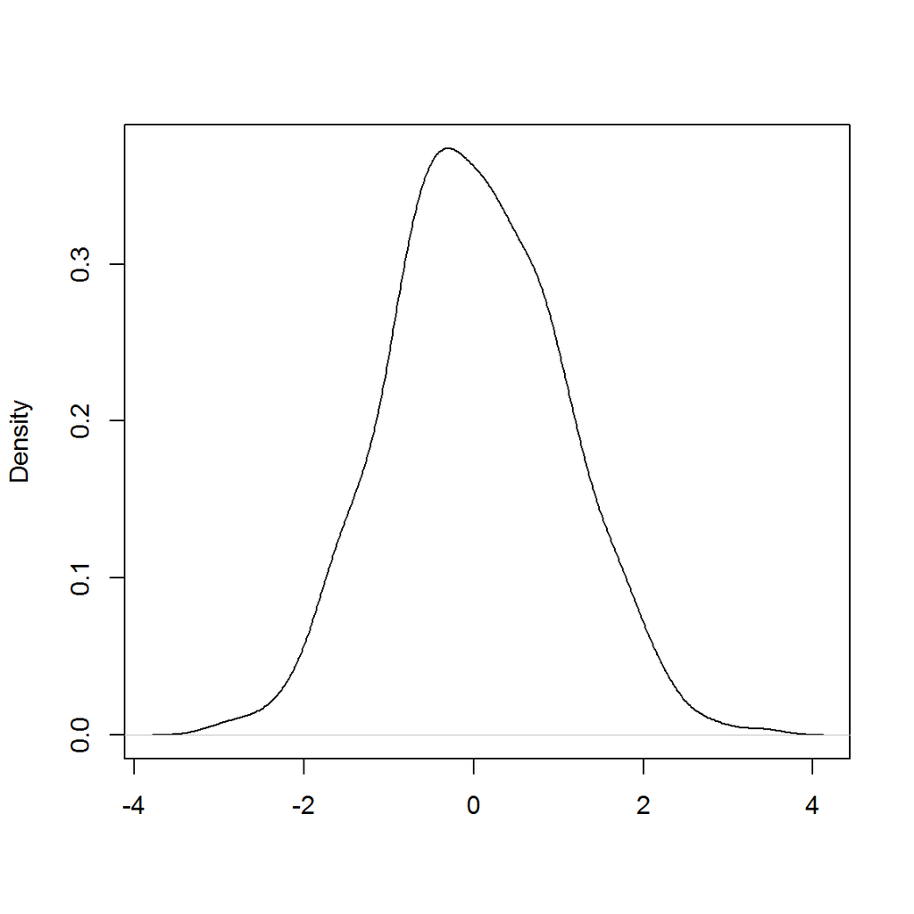

```r
B=1000
set.seed(1)
x=rnorm(12,1,1);y=rnorm(8)
z=c(x,y);tobs=(mean(x)-mean(y))/(var(z)*sqrt(1/12+1/8))
BS=matrix(0,B,20)
Be=c()
for (i in 1:B)
  {
  BS[i,]=sample(c(x,y),replace=T)
  bs1=BS[i,1:12];bs2=BS[i,13:20]
  Be[i]=(mean(bs1)-mean(bs2))/(var(BS[i,])*sqrt(1/12+1/8))
}
plot(density(Be),main="",xlab="")
```

```r
p=mean(Be>tobs)
p
```

```
## [1] 0.017
```

## 4. Smoothed Bootstrap

붓스트랩 표본을 추출하는 $\hat F_n$은 이산형 분포함수이다. 따라서, 실제 모집단의 분포가 연속형인 경우에는 예기치 않은 noise가 발생할 수 있다. 이러한 현상은 관심대상인 통계량이 분위수나 경계값(극단치)등을 경우에 심화되는 것으로 알려져 있다. 지난 챕터에서 $U(0,\theta)$ 분포에서 $\hat\theta = X_{(n)}$의 분포에 대한 붓스트랩 추정이 잘 되지 않았던 것을 기억하여 보아라.

이러한 경우, $\hat F_n$을 연속형으로 수정해 주는 방식으로 문제를 해결할 수 있음이 알려져 있다.

관측된 표본을 $X=(X_1,\ldots,X_n)$이라 하자.

- step 1 : $X$로 부터 붓스트랩 표본 $X^\ast = (X_1^\ast,\ldots,X_n^\ast)$ 추출
- step 2 : $X_{i,s}^\ast = X_i^\ast + h\epsilon_i$ 생성. 여기서 $h$는 평활모수로 적절히 선택되어야 하며, $\epsilon_i$는 평활을 위한 커널(kernel)밀도함수 $K(\cdot)$으로부터 임의로 추출된 표본이다.
- step 3 : 위 과정을 $B$번 반복하여 붓스트랩 추정량을 얻음.

즉, $h\epsilon_i$ 부분이 기존 표본에 random noise를 주어 부드럽게 만들어 주는 것이다.
cf) $X_1,\ldots,X_n$에 근거한 Kernel density estimator
$$\hat f_h(x)=\frac{1}{nh}\sum_{i=1}^n K(\frac{X_i-x}{h})$$
에 근거하여 계산된 분포함수 $\hat F_h(\cdot)$으로부터의 임의표본이 $X_{1,s}^\ast,\ldots,X_{n,s}^\ast$이 됨이 알려져 있다.

$h$의 선택은 매우 중요하고 연구가 많이 되어 있으며, $K$은 보통 normal density나 $K(u)=(4/3)(1-u^2)I(|u|<1)$과 같은 밀도함수를 흔히 사용하나 어떤 것을 사용하여도 크게 영향을 미치지 않는 것으로 알려져 있다.

- Example : Exp(10)으로부터 $n=100$ 표본 추출하여 95% 분위수의 분포 추정

```r
B=5000
set.seed(1)
x=rexp(100,1/10)
BS=sBS=matrix(0,B,100)
Bq=sBq=c()
eq=quantile(x,0.95);tq=qexp(0.95,1/10)
c(eq,tq)
```

```
##      95%
## 28.95714 29.95732
```

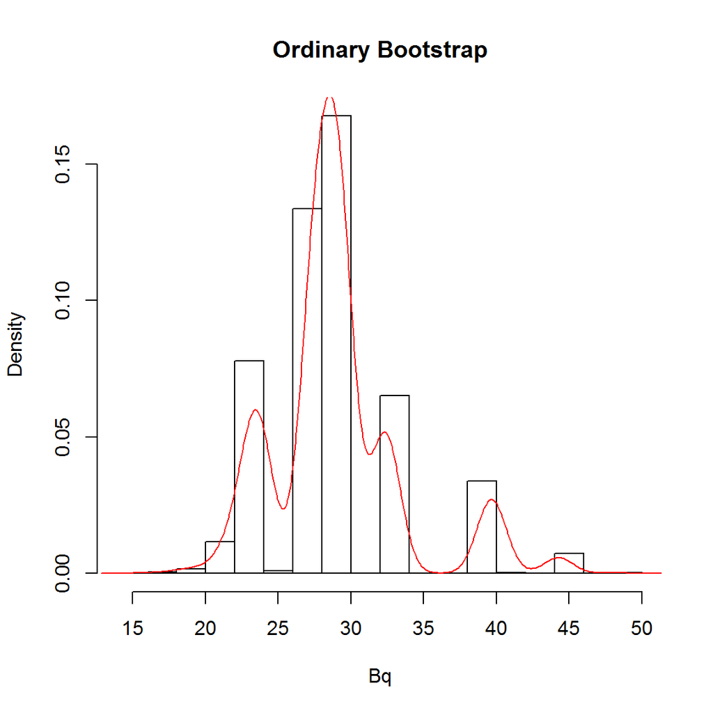

```r
h=density(x)$bw
for (i in 1:B)
  {
  BS[i,]=sample(x,replace=T)
  Bq[i]=quantile(BS[i,],0.95)
  sBS[i,]=sample(x,replace=T)+h*rnorm(100)
  sBq[i]=quantile(sBS[i,],0.95)
}
hist(Bq,main="Ordinary Bootstrap",freq=F)
lines(density(Bq,bw=1),col=2)
```

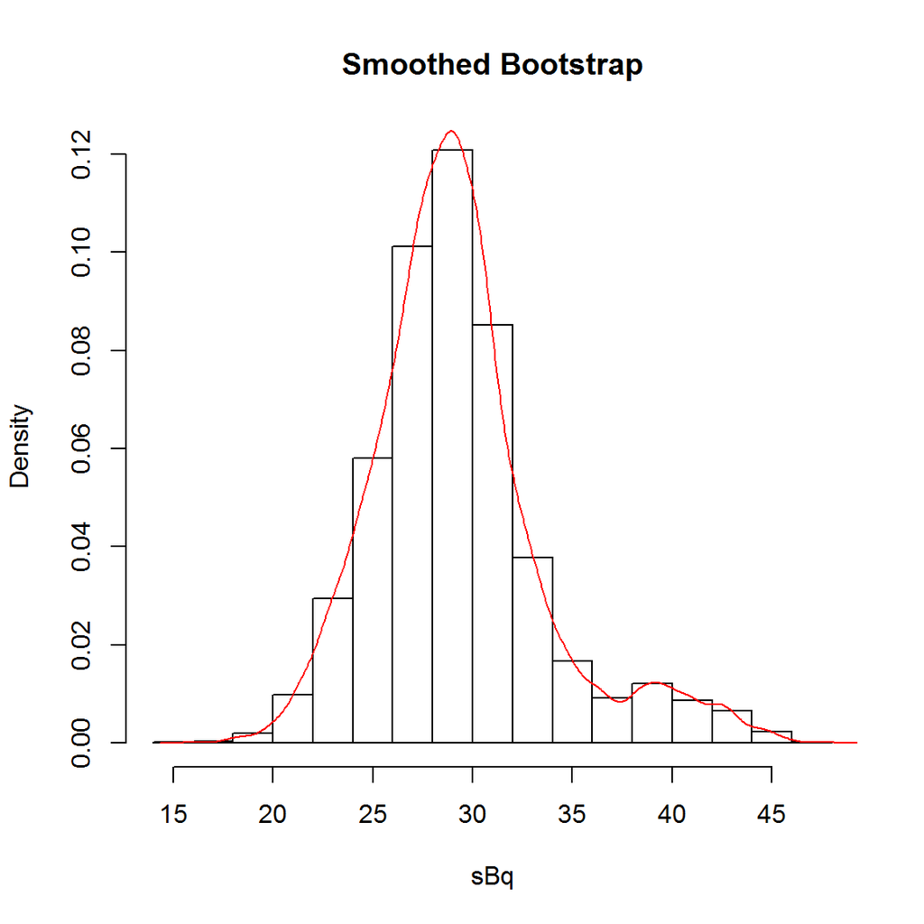

```r
hist(sBq,main="Smoothed Bootstrap",freq=F)
lines(density(sBq),col=2)
```

- Example : $U(0,\theta)$

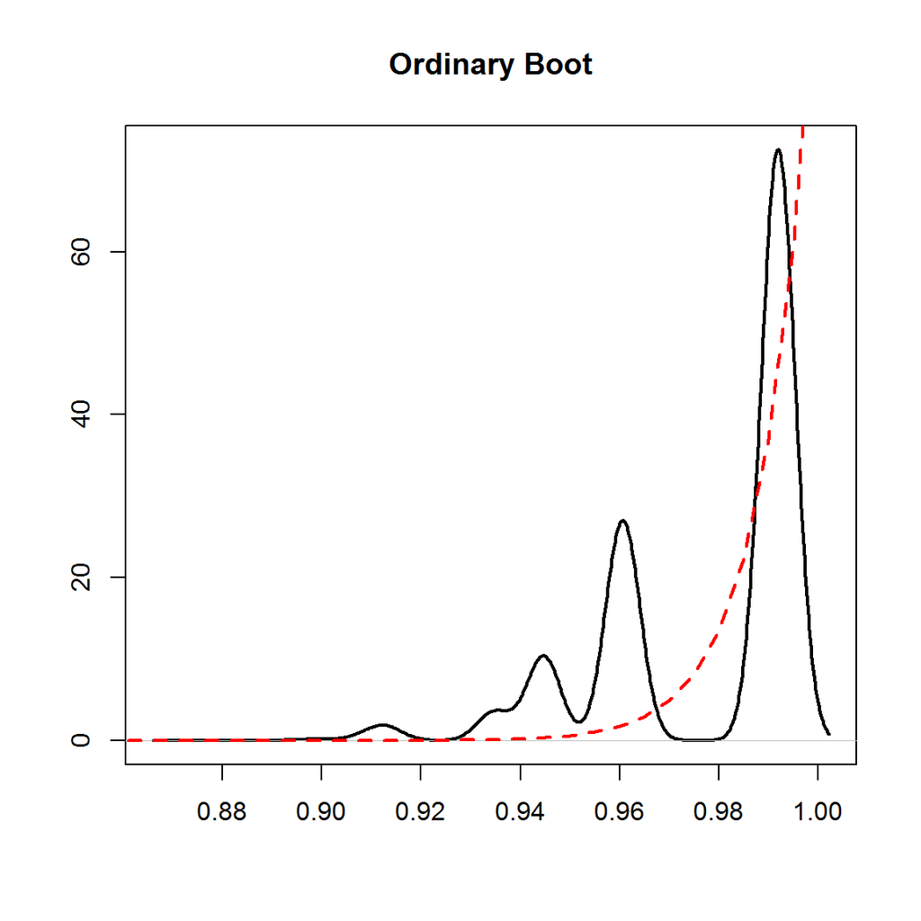

```r
n=100
B=5000
set.seed(1)
theta=1
x=runif(n)
bm=bm1=c()
xb=xb1=matrix(0,B,n)
h=density(x)$bw
for (i in 1:B)
    {
    xb[i,]=sample(x,replace=TRUE)
    bm[i]=max(xb[i,])
    }
plot(density(bm),main="Ordinary Boot",xlab="",ylab="",lwd=2)
lines(seq(0,1,0.005),n*seq(0,1,0.005)^(n-1),lwd=2,lty=2,col=2)
```

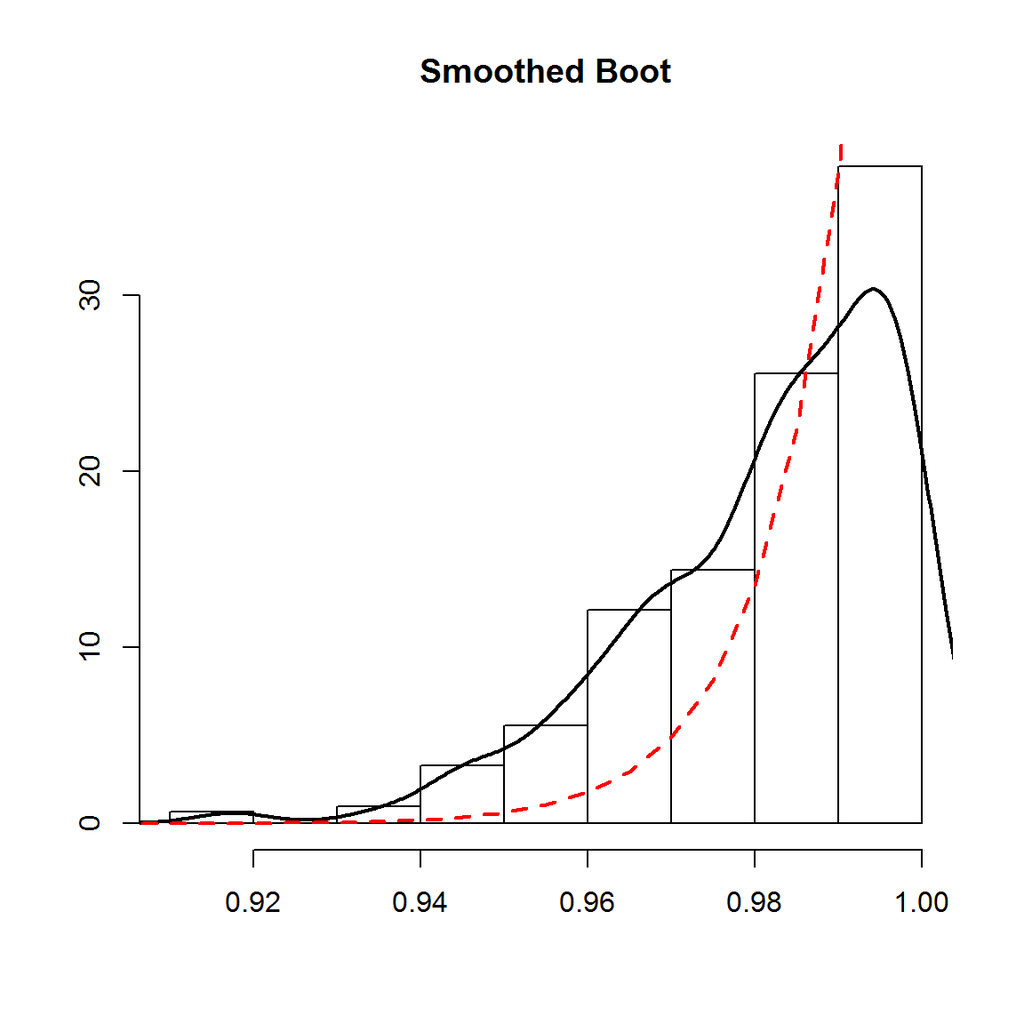

```r
for (i in 1:B)
    {
    xb1[i,]=sample(x,replace=TRUE)+h*rnorm(n)
    bm1[i]=max(xb1[i,])
}
hist(bm1[bm1<1],main="Smoothed Boot",xlab="",ylab="",freq=F)
lines(density(bm1[bm1<1]),lwd=2)
lines(seq(0,1,0.005),n*seq(0,1,0.005)^(n-1),lwd=2,lty=2,col=2)
```

cf1) smoothed 붓스트랩 표본은 원래 붓스트랩 표본과 분산이 다르기 때문에 이에 대한 수정이 필요하다. (여기서는 언급하지 않았음.) cf2) 위 예에서 최대값의 표본분포를 찾는 문제는 support boundary의 문제 때문에 좀 더 정밀한 방법이 필요하다. 위 예에서는 아주 간략하게만 수정하였다.